# A simple SQL-backend for Spectra metadata

Laurent Gatto, Chong Tang

27 April 2020

# 1 Introduction

In this vignette, we want to benchmark 2 backends for the package `Spectra`: `MsBackendSql` and `MsBackendMzR`, to evaluate whether the new backend `MsBackendSql` can reduce the RAM consumption.

# 2 Usage

We will need the following packages:

```r
library(MsBackendSql)
library(Spectra)
library(mzR)
library(RSQLite)
library(msdata)
library(peakRAM)
library(tidyverse)
library(pryr)
```

The example below demonstrates the functionality of `MsBackendSql` with a single file:

```r
f <- msdata::proteomics(full.names = TRUE)[4]
conn1 <- dbConnect(SQLite(), "b1.db")
b1 <- backendInitialize(MsBackendSqlDb(), dbcon = conn1, files = f)
object_size(b1)
```

```
## 38 kB
```

We can also load the raw `mzML` file with `MsBackendMzR` backend.

```r
b2 <- Spectra::backendInitialize(MsBackendMzR(), files = f)
object_size(b2)
```

```
## 2.84 MB
```

# 3 Benchmarking

In the code chunks below, we open respectively 1, 10, 20, 50, 100 and 200 times the same file and record the elapsed time (in seconds), the peak amount of RAM used (MiB) and the amount of RAM used after completion of the function:

```r
conn1 <- dbConnect(SQLite(), "bench1.db")
peakram1 <- peakRAM(sqlb1 <- backendInitialize(MsBackendSqlDb(), dbcon = conn1, files = f))
conn10 <- dbConnect(SQLite(), "bench10.db")
peakram10 <- peakRAM(sqlb10 <- backendInitialize(MsBackendSqlDb(), dbcon = conn10, rep(f, 10)))
conn20 <- dbConnect(SQLite(), "bench20.db")
peakram20 <- peakRAM(sqlb20 <- backendInitialize(MsBackendSqlDb(), dbcon = conn20, rep(f, 20)))
conn50 <- dbConnect(SQLite(), "bench50.db")
peakram50 <- peakRAM(sqlb50 <- backendInitialize(MsBackendSqlDb(), dbcon = conn50, rep(f, 50)))
conn100 <- dbConnect(SQLite(), "bench100.db")
peakram100 <- peakRAM(sqlb100 <- backendInitialize(MsBackendSqlDb(), dbcon = conn100, rep(f, 100)))
conn200 <- dbConnect(SQLite(), "bench200.db")
peakram200 <- peakRAM(sqlb200 <- backendInitialize(MsBackendSqlDb(), dbcon = conn200, rep(f, 200)))

n <- c(1, 10, 20, 50, 100, 200)

res1 <- vector(mode = "list", length = 6)
for (i in seq_along(n)) {
    fls  <-  rep(f, n[i])
    res1[[i]] <- peakRAM(b1 <- Spectra::backendInitialize(MsBackendMzR(), files = fls))
}

save(peakram1, peakram10, peakram20,
     peakram50, peakram100, peakram200, res1,
     file = "peakRAM_SQL.rda")
```

We repeatedly stored the metadata as SQLite tables in the following SQLite databases. Below, we retrieved each single metadata table in the SQLite database, and checked their RAM consumptions (MiB) and the file size (MB).

```r
db_files <- dir(pattern = "bench.*db")
db_files <- db_files[order(as.numeric(sub("\\.db", "", sub("bench", "", db_files))))]
dbfile_size <- file.size(db_files) / 1024^2
```

The benchmarking data:

```r
load("peakRAM_SQL.rda")
dfr <- data.frame(rbind(peakram1, peakram10, peakram20,
                        peakram50, peakram100, peakram200),
                  dbfile_size,
                  n = c(1, 10, 20, 50, 100, 200)) %>%
    select(-1)
dfr
```

```
##   Elapsed_Time_sec Total_RAM_Used_MiB Peak_RAM_Used_MiB dbfile_size   n
## 1           16.091                  0            1223.5    581.9883   1
## 2          157.965                  0            1407.3   5819.8789  10
## 3          317.991                  0            1452.3  11639.7578  20
## 4          796.534                  0            1461.1  29099.4062  50
## 5         1592.226                  0            1430.9  58198.8164 100
## 6         3156.715                  0            1471.0 116397.6289 200
```

```r
ram_records <- res1 %>% bind_rows(.)
dfr1 <- data.frame(rbind(peakram1, peakram10, peakram20,
                        peakram50, peakram100, peakram200),
                        ram_records[-1],
                   n = c(1, 10, 20, 50, 100, 200)) %>%
    select(-1)
dfr1
```

```
##   Elapsed_Time_sec Total_RAM_Used_MiB Peak_RAM_Used_MiB Elapsed_Time_sec.1
## 1           16.091                  0            1223.5              5.180
## 2          157.965                  0            1407.3              8.482
## 3          317.991                  0            1452.3             16.930
## 4          796.534                  0            1461.1             42.282
## 5         1592.226                  0            1430.9             83.615
## 6         3156.715                  0            1471.0            166.863
##   Total_RAM_Used_MiB.1 Peak_RAM_Used_MiB.1   n
## 1                  1.5                 8.0   1
## 2                 13.5                80.1  10
## 3                 15.0               151.3  20
## 4                 44.8               191.1  50
## 5                 74.7               331.7 100
## 6                149.5               742.7 200
```

# 4 Results

Firstly, we want to compare the RAM consumptions with the local on-disk SQL database sizes.

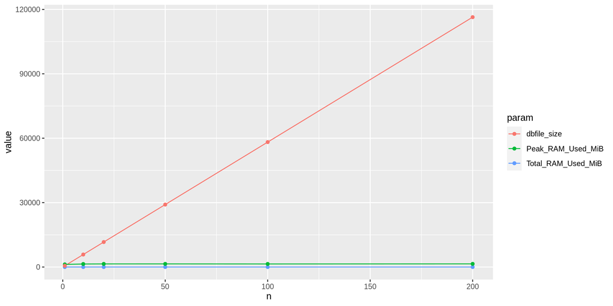

```r
dfr %>%
    select(n, Total_RAM_Used_MiB, Peak_RAM_Used_MiB, dbfile_size) %>%
    pivot_longer(names_to = "param",
                 values_to = "value",
                 -n) %>%
    ggplot(aes(x = n, y = value, colour = param)) +
    geom_line() +
    geom_point()
```

Below, we also want to benchmark the differences between `MsBackendSql` and `MsBackendMzR`. We can notice that `MsBackendMzR` is much faster than `MsBackendSql` for data reading.

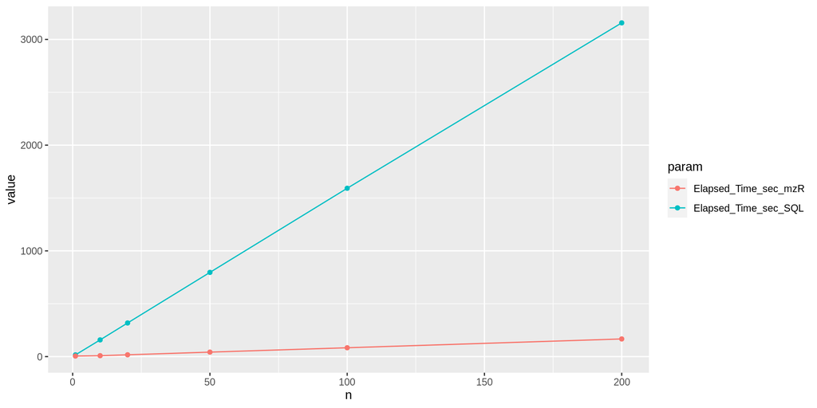

```r
dfr1 %>%
    select(n, Elapsed_Time_sec_SQL = Elapsed_Time_sec,
           Elapsed_Time_sec_mzR = Elapsed_Time_sec.1) %>%
    pivot_longer(names_to = "param",
                 values_to = "value",
                 -n) %>%
    ggplot(aes(x = n, y = value, colour = param)) +
    geom_line() +
    geom_point()
```

The total RAM consumption is also within our expectation, `MsBackendSql` backend can greatly reduce the RAM consumtion by storing metadata into SQLite database.

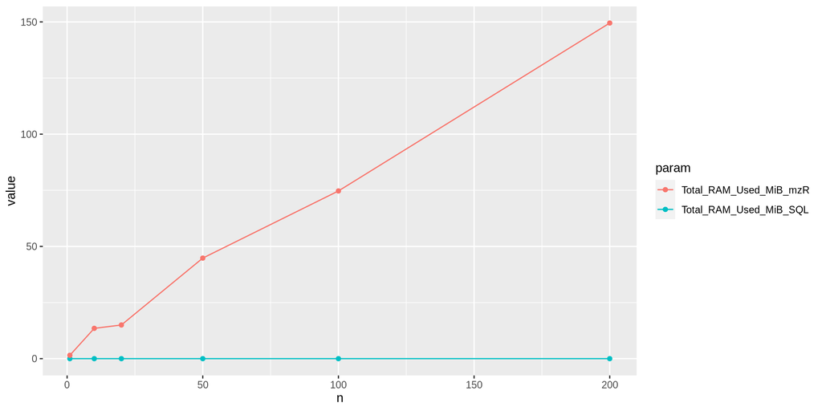

```r
dfr1 %>%
        select(n, Total_RAM_Used_MiB_SQL = Total_RAM_Used_MiB,
               Total_RAM_Used_MiB_mzR = Total_RAM_Used_MiB.1) %>%
        pivot_longer(names_to = "param",
                     values_to = "value",
                     -n) %>%
        ggplot(aes(x = n, y = value, colour = param)) +
        geom_line() +
        geom_point()
```

The final plot shows that the new backend `MsBackendSql` requires more RAM consumption on the peak than `MsBackendMzR`.

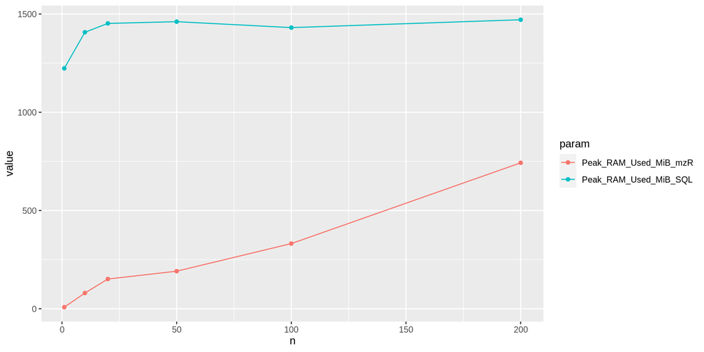

```r
dfr1 %>%
        select(n, Peak_RAM_Used_MiB_SQL = Peak_RAM_Used_MiB,
               Peak_RAM_Used_MiB_mzR = Peak_RAM_Used_MiB.1) %>%
        pivot_longer(names_to = "param",
                     values_to = "value",
                     -n) %>%
        ggplot(aes(x = n, y = value, colour = param)) +
        geom_line() +
        geom_point()
```